# notebook

## 1. The Statcast revolution

[figure not shown]

This is Aaron Judge. Judge is one of the physically largest players in Major League Baseball standing 6 feet 7 inches (2.01 m) tall and weighing 282 pounds (128 kg). He also hit the [hardest home run](https://www.mlb.com/news/aaron-judge-sets-statcast-exit-velocity-record/c-235640846) ever recorded. How do we know this? **Statcast**.

Statcast is a state-of-the-art tracking system that uses high-resolution cameras and radar equipment to measure the precise location and movement of baseballs and baseball players. Introduced in 2015 to all 30 major league ballparks, Statcast data is revolutionizing the game. Teams are engaging in an "arms race" of data analysis, hiring analysts left and right in an attempt to gain an edge over their competition. This [video](https://www.youtube.com/watch?v=9rOKGKhQe8U) describing the system is incredible.

**In this notebook**, we're going to wrangle, analyze, and visualize Statcast data to compare Mr. Judge and another (extremely large) teammate of his. Let's start by loading the data into our Notebook. There are two CSV files, `judge.csv` and `stanton.csv`, both of which contain Statcast data for 2015-2017. We'll use pandas DataFrames to store this data. Let's also load our data visualization libraries, matplotlib and seaborn.

```python
import pandas as pd
import matplotlib.pyplot as plt
import seaborn as sns
%matplotlib inline

# Load Aaron Judge's Statcast data
judge = pd.read_csv('datasets/judge.csv')

# Load Giancarlo Stanton's Statcast data
stanton = pd.read_csv('datasets/stanton.csv')
```

```python
%%nose

import pandas as pd

def test_judge_correctly_loaded():
    correct_judge = pd.read_csv("datasets/judge.csv")
    assert correct_judge.equals(judge), "The variable `judge` should contain the data in `judge.csv`"

def test_stanton_correctly_loaded():
    correct_stanton = pd.read_csv("datasets/stanton.csv")
    assert correct_stanton.equals(stanton), "The variable `stanton` should contain the data in `stanton.csv`"
```

```
2/2 tests passed
```

## 2. What can Statcast measure?

The better question might be, what can't Statcast measure?

> Starting with the pitcher, Statcast can measure simple data points such as velocity. At the same time, Statcast digs a whole lot deeper, also measuring the release point and spin rate of every pitch.

> Moving on to hitters, Statcast is capable of measuring the exit velocity, launch angle and vector of the ball as it comes off the bat. From there, Statcast can also track the hang time and projected distance that a ball travels.

Let's inspect the last five rows of the `judge` DataFrame. You'll see that each row represents one pitch thrown to a batter. You'll also see that some columns have esoteric names. If these don't make sense now, don't worry. The relevant ones will be explained as necessary.

```python
# Display all columns (pandas will collapse some columns if we don't set this option)
pd.set_option('display.max_columns', None)

# Display the last five rows of the Aaron Judge file
# ... YOUR CODE FOR TASK 2 ...
judge.tail()
```

|  | pitch_type | game_date | release_speed | release_pos_x | release_pos_z | player_name | batter | pitcher | events | description | spin_dir | spin_rate_deprecated | break_angle_deprecated | break_length_deprecated | zone | des | game_type | stand | p_throws | home_team | away_team | type | hit_location | bb_type | balls | strikes | game_year | pfx_x | pfx_z | … |
| --- | --- | --- | --- | --- | --- | --- | --- | --- | --- | --- | --- | --- | --- | --- | --- | --- | --- | --- | --- | --- | --- | --- | --- | --- | --- | --- | --- | --- | --- | --- |
| 3431 | CH | 2016-08-13 | 85.6 | -1.9659 | 5.9113 | Aaron Judge | 592450 | 542882 | NaN | ball | NaN | NaN | NaN | NaN | 14.0 | NaN | R | R | R | NYY | TB | B | NaN | NaN | 0 | 0 | 2016 | -0.379108 | 0.370567 | … |
| 3432 | CH | 2016-08-13 | 87.6 | -1.9318 | 5.9349 | Aaron Judge | 592450 | 542882 | home_run | hit_into_play_score | NaN | NaN | NaN | NaN | 4.0 | Aaron Judge homers (1) on a fly ball to center... | R | R | R | NYY | TB | X | NaN | fly_ball | 1 | 2 | 2016 | -0.295608 | 0.320400 | … |
| 3433 | CH | 2016-08-13 | 87.2 | -2.0285 | 5.8656 | Aaron Judge | 592450 | 542882 | NaN | ball | NaN | NaN | NaN | NaN | 14.0 | NaN | R | R | R | NYY | TB | B | NaN | NaN | 0 | 2 | 2016 | -0.668575 | 0.198567 | … |
| 3434 | CU | 2016-08-13 | 79.7 | -1.7108 | 6.1926 | Aaron Judge | 592450 | 542882 | NaN | foul | NaN | NaN | NaN | NaN | 4.0 | NaN | R | R | R | NYY | TB | S | NaN | NaN | 0 | 1 | 2016 | 0.397442 | -0.614133 | … |
| 3435 | FF | 2016-08-13 | 93.2 | -1.8476 | 6.0063 | Aaron Judge | 592450 | 542882 | NaN | called_strike | NaN | NaN | NaN | NaN | 8.0 | NaN | R | R | R | NYY | TB | S | NaN | NaN | 0 | 0 | 2016 | -0.823050 | 1.623300 | … |

```python
%%nose

# No standard testing procedure exists for printing at the moment

def test_nothing():
    assert True, "Nothing to test"
```

```
1/1 tests passed
```

## 3. Aaron Judge and Giancarlo Stanton, prolific sluggers

[figure not shown]

This is Giancarlo Stanton. He is also a very large human being, standing 6 feet 6 inches tall and weighing 245 pounds. Despite not wearing the same jersey as Judge in the pictures provided, in 2018 they will be teammates on the New York Yankees. They are similar in a lot of ways, one being that they hit a lot of home runs. Stanton and Judge led baseball in home runs in 2017, with [59](https://www.youtube.com/watch?v=tJ6Bz5P6dg4) and [52](https://www.youtube.com/watch?v=Gw3pFHMM9fk), respectively. These are exceptional totals - the player in third "only" had 45 home runs.

```python
# All of Aaron Judge's batted ball events in 2017
judge_events_2017 = judge[judge.game_date.str.contains('2017')]['events']
print("Aaron Judge batted ball event totals, 2017:")
print(judge_events_2017.nunique())

# All of Giancarlo Stanton's batted ball events in 2017
stanton_events_2017 = stanton[stanton.game_date.str.contains('2017')]['events']
print("\nGiancarlo Stanton batted ball event totals, 2017:")
print(stanton_events_2017.nunique())
```

```
Aaron Judge batted ball event totals, 2017:
15

Giancarlo Stanton batted ball event totals, 2017:
15
```

```python
%%nose

def test_judge_events_2017_correct():
    correct_judge_events_2017 = judge.loc[judge['game_year'] == 2017].events
    assert correct_judge_events_2017.equals(judge_events_2017), "The variable `judge_events_2017` should contain the `events` column from the `judge` DataFrame after filtering for all pitches that occurred in 2017"

def test_stanton_events_2017_correct():
    correct_stanton_events_2017 = stanton.loc[stanton['game_year'] == 2017].events
    assert correct_stanton_events_2017.equals(stanton_events_2017), "The variable `stanton_events_2017` should contain the `events` column from the `stanton` DataFrame after filtering for all pitches that occurred in 2017"
```

```
2/2 tests passed
```

## 4. Analyzing home runs with Statcast data

- [Launch angle](http://m.mlb.com/glossary/statcast/launch-angle): the vertical angle at which the ball leaves a player's bat
- [Exit velocity](http://m.mlb.com/glossary/statcast/exit-velocity): the speed of the baseball as it comes off the bat

This new data has changed the way teams value both hitters and pitchers. Why? As per the [Washington Post](https://www.washingtonpost.com/graphics/sports/mlb-launch-angles-story/?utm_term=.8d088d31f098):

> Balls hit with a high launch angle are more likely to result in a hit. Hit fast enough and at the right angle, they become home runs.

Let's look at exit velocity vs. launch angle and let's focus on home runs only (2015-2017). The first two plots show data points. The second two show smoothed contours to represent density.

```
Text(0.5,1,'Giancarlo Stanton\nHome Runs, 2015-2017')
```

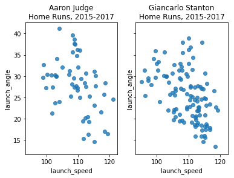

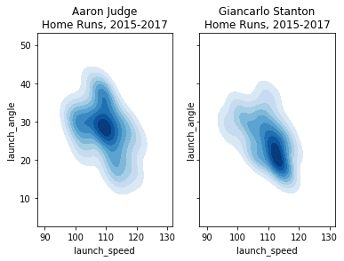

```python
# Filter to include home runs only
judge_hr = judge[judge.events=='home_run']
stanton_hr = stanton[stanton.events=='home_run']

# Create a figure with two scatter plots of launch speed vs. launch angle, one for each player's home runs
fig1, axs1 = plt.subplots(ncols=2, sharex=True, sharey=True)
sns.regplot(x='launch_speed', y='launch_angle', fit_reg=False, color='tab:blue', data=judge_hr, ax=axs1[0]).set_title('Aaron Judge\nHome Runs, 2015-2017')
sns.regplot(x='launch_speed', y='launch_angle', fit_reg=False, color='tab:blue', data=stanton_hr, ax=axs1[1]).set_title('Giancarlo Stanton\nHome Runs, 2015-2017')

# Create a figure with two KDE plots of launch speed vs. launch angle, one for each player's home runs
fig2, axs2 = plt.subplots(ncols=2, sharex=True, sharey=True)
sns.kdeplot(data=judge_hr.launch_speed,data2=judge_hr.launch_angle, cmap="Blues", shade=True, shade_lowest=False, ax=axs2[0]).set_title('Aaron Judge\nHome Runs, 2015-2017')
sns.kdeplot(data=stanton_hr.launch_speed, data2=stanton_hr.launch_angle, cmap="Blues", shade=True, shade_lowest=False, ax=axs2[1]).set_title('Giancarlo Stanton\nHome Runs, 2015-2017')
```

```python
%%nose

import pandas as pd

def test_judge_hr_correct():
    correct_judge_hr = judge.loc[judge['events'] == 'home_run']
    assert correct_judge_hr.equals(judge_hr), "The variable `judge_hr` should contain all pitches in `judge` that resulted in a home run"

def test_stanton_hr_correct():
    correct_stanton_hr = stanton.loc[stanton['events'] == 'home_run']
    assert correct_stanton_hr.equals(stanton_hr), "The variable `stanton_hr` should contain all pitches in `stanton` that resulted in a home run"

# No standard testing procedure exists for plots at the moment
```

```
2/2 tests passed
```

## 5. Home runs by pitch velocity

It appears that Stanton hits his home runs slightly lower and slightly harder than Judge, though this needs to be taken with a grain of salt given the small sample size of home runs.

```
Text(0.5,1,'Home Runs, 2015-2017')
```

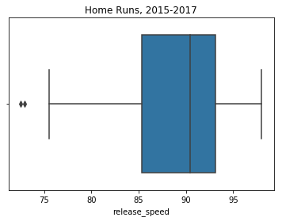

```python
# Combine the Judge and Stanton home run DataFrames for easy boxplot plotting
judge_stanton_hr = pd.concat([judge_hr,stanton_hr])

# Create a boxplot that describes the pitch velocity of each player's home runs
sns.boxplot(judge_stanton_hr.release_speed).set_title('Home Runs, 2015-2017')
```

```python
%%nose

def test_judge_stanton_hr_correct():
    correct_judge_stanton_hr = pd.concat([judge_hr, stanton_hr])
    also_correct_judge_stanton_hr = pd.concat([stanton_hr, judge_hr])
    assert correct_judge_stanton_hr.equals(judge_stanton_hr) or \
        also_correct_judge_stanton_hr.equals(judge_stanton_hr), \
        "The variable `judge_stanton_hr` should be the concatenation of `judge_hr` and `stanton_hr`"

# No standard testing procedure exists for plots at the moment
```

```
1/1 tests passed
```

## 6. Home runs by pitch location (I)

[figure not shown]

```python
def assign_x_coord(row):
    """
    Assigns an x-coordinate to Statcast's strike zone numbers. Zones 11, 12, 13,
    and 14 are ignored for plotting simplicity.
    """
    # Left third of strike zone
    if row.zone in [1, 4, 7]:
        # ... YOUR CODE FOR TASK 6 ...
        return 1
    # Middle third of strike zone
    if row.zone in [2, 5, 8]:
        # ... YOUR CODE FOR TASK 6 ...
        return 2
    # Right third of strike zone
    if row.zone in [3, 6, 9]:
        # ... YOUR CODE FOR TASK 6 ...
        return 3
```

```python
%%nose

def test_assign_x_coord():
    dummy_zone_x = [{'zone': 1},
                    {'zone': 2},
                    {'zone': 3},
                    {'zone': 4},
                    {'zone': 5},
                    {'zone': 6},
                    {'zone': 7},
                    {'zone': 8},
                    {'zone': 9}]
    df_dummy_zone_x = pd.DataFrame(dummy_zone_x)
    df_dummy_zone_x['zone_x'] = df_dummy_zone_x.apply(assign_x_coord, axis=1)

    correct_zone_x = [{'zone': 1, 'zone_x': 1},
                      {'zone': 2, 'zone_x': 2},
                      {'zone': 3, 'zone_x': 3},
                      {'zone': 4, 'zone_x': 1},
                      {'zone': 5, 'zone_x': 2},
                      {'zone': 6, 'zone_x': 3},
                      {'zone': 7, 'zone_x': 1},
                      {'zone': 8, 'zone_x': 2},
                      {'zone': 9, 'zone_x': 3}]
    df_correct_zone_x = pd.DataFrame(correct_zone_x)

    assert df_correct_zone_x.equals(df_dummy_zone_x), "At least one of the zone's assigned x-coordinates are incorrect"
```

```
1/1 tests passed
```

## 7. Home runs by pitch location (II)

And let's do the same but for y-coordinates.

```python
def assign_y_coord(row):
    """
    Assigns a y-coordinate to Statcast's strike zone numbers. Zones 11, 12, 13,
    and 14 are ignored for plotting simplicity.
    """
    # Upper third of strike zone
    # ... YOUR CODE FOR TASK 7 ...
    if row.zone in [1,2,3]:
        return 3
    # Middle third of strike zone
    # ... YOUR CODE FOR TASK 7 ...
    if row.zone in [4,5,6]:
        return 2
    # Lower third of strike zone
    # ... YOUR CODE FOR TASK 7 ...
    if row.zone in [7,8,9]:
        return 1
```

```python
%%nose

def test_assign_y_coord():
    dummy_zone_y = [{'zone': 1},
                    {'zone': 2},
                    {'zone': 3},
                    {'zone': 4},
                    {'zone': 5},
                    {'zone': 6},
                    {'zone': 7},
                    {'zone': 8},
                    {'zone': 9}]
    df_dummy_zone_y = pd.DataFrame(dummy_zone_y)
    df_dummy_zone_y['zone_y'] = df_dummy_zone_y.apply(assign_y_coord, axis=1)

    correct_zone_y = [{'zone': 1, 'zone_y': 3},
                      {'zone': 2, 'zone_y': 3},
                      {'zone': 3, 'zone_y': 3},
                      {'zone': 4, 'zone_y': 2},
                      {'zone': 5, 'zone_y': 2},
                      {'zone': 6, 'zone_y': 2},
                      {'zone': 7, 'zone_y': 1},
                      {'zone': 8, 'zone_y': 1},
                      {'zone': 9, 'zone_y': 1}]
    df_correct_zone_y = pd.DataFrame(correct_zone_y)

    assert df_correct_zone_y.equals(df_dummy_zone_y), "At least one of the zone's assigned y-coordinates are incorrect"
```

```
1/1 tests passed
```

## 8. Aaron Judge's home run zone

Now we can apply the functions we've created then construct our 2D histograms. First, for Aaron Judge (again, for pitches in the strike zone that resulted in home runs).

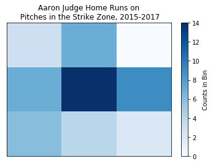

```python
# Zones 11, 12, 13, and 14 are to be ignored for plotting simplicity
judge_strike_hr = judge_hr.copy().loc[judge_hr.zone <= 9]

# Assign Cartesian coordinates to pitches in the strike zone for Judge home runs
judge_strike_hr['zone_x'] = judge_strike_hr.apply(assign_x_coord,axis=1)
judge_strike_hr['zone_y'] = judge_strike_hr.apply(assign_y_coord,axis=1)

# Plot Judge's home run zone as a 2D histogram with a colorbar
plt.hist2d(judge_strike_hr.zone_x, judge_strike_hr.zone_y, bins = 3, cmap='Blues')
plt.title('Aaron Judge Home Runs on\n Pitches in the Strike Zone, 2015-2017')
plt.gca().get_xaxis().set_visible(False)
plt.gca().get_yaxis().set_visible(False)
cb = plt.colorbar()
cb.set_label('Counts in Bin')
```

```python
%%nose

def test_judge_strike_hr_correct():
    correct_judge_strike_hr = judge_hr.copy().loc[judge_hr.zone <= 9]
    correct_judge_strike_hr['zone_x'] = correct_judge_strike_hr.apply(assign_x_coord, axis=1)
    correct_judge_strike_hr['zone_y'] = correct_judge_strike_hr.apply(assign_y_coord, axis=1)
    assert correct_judge_strike_hr.equals(judge_strike_hr), "The `zone_x` and `zone_y` columns of `judge_strike_hr` should contain each zone's Cartesian coordinates"

# No standard testing procedure exists for plots at the moment
```

```
1/1 tests passed
```

## 9. Giancarlo Stanton's home run zone

And now for Giancarlo Stanton.

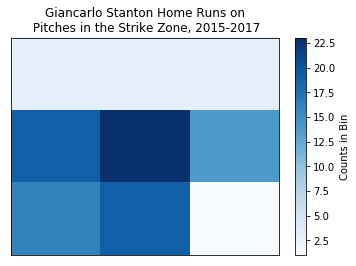

```python
# Zones 11, 12, 13, and 14 are to be ignored for plotting simplicity
stanton_strike_hr = stanton_hr.copy().loc[stanton_hr.zone <= 9]

# Assign Cartesian coordinates to pitches in the strike zone for Stanton home runs
# ... YOUR CODE FOR TASK 9 ...
# ... YOUR CODE FOR TASK 9 ...
stanton_strike_hr['zone_x'] = stanton_strike_hr.apply(assign_x_coord,axis=1)
stanton_strike_hr['zone_y'] = stanton_strike_hr.apply(assign_y_coord,axis=1)

# Plot Stanton's home run zone as a 2D histogram with a colorbar
# ... YOUR CODE FOR TASK 9 ...
plt.hist2d(stanton_strike_hr.zone_x, stanton_strike_hr.zone_y, bins = 3, cmap='Blues')
plt.title('Giancarlo Stanton Home Runs on\n Pitches in the Strike Zone, 2015-2017')
plt.gca().get_xaxis().set_visible(False)
plt.gca().get_yaxis().set_visible(False)
cb = plt.colorbar()
cb.set_label('Counts in Bin')
```

```python
%%nose

def test_stanton_strike_hr_correct():
    correct_stanton_strike_hr = stanton_hr.copy().loc[stanton_hr.zone <= 9]
    correct_stanton_strike_hr['zone_x'] = correct_stanton_strike_hr.apply(assign_x_coord, axis=1)
    correct_stanton_strike_hr['zone_y'] = correct_stanton_strike_hr.apply(assign_y_coord, axis=1)
    assert correct_stanton_strike_hr.equals(stanton_strike_hr), "The `zone_x` and `zone_y` columns of `stanton_strike_hr` should contain each zone's Cartesian coordinates"

# No standard testing procedure exists for plots at the moment
```

```
1/1 tests passed
```

## 10. Should opposing pitchers be scared?

A few takeaways:

- Stanton does not hit many home runs on pitches in the upper third of the strike zone.
- Like pretty much every hitter ever, both players love pitches in the horizontal and vertical middle of the plate.
- Judge's least favorite home run pitch appears to be high-away while Stanton's appears to be low-away.
- If we were to describe Stanton's home run zone, it'd be middle-inside. Judge's home run zone is much more spread out.

Should opposing pitchers still be scared?

```python
# Should opposing pitchers be wary of Aaron Judge and Giancarlo Stanton
should_pitchers_be_scared = True
```

```python
%%nose

def test_scared():
    assert should_pitchers_be_scared == True, "Pitchers should be scared of Aaron Judge and Giancarlo Stanton! They are scary!"
```

```
1/1 tests passed
```